# Class 13: Social Movements online, in effect, dying out, and going forward

Demobilisation

Author

[Dr. Michael C. Zeller](https://michaelzeller.de)

# Opening notes

[Open Sticker](https://tenor.com/view/open-gif-14209777)from [Open Stickers](https://tenor.com/search/open-stickers)

# Key concepts review

- social movements - collections of people that mobilise, coordinate, and campaign for some objective
- essay question example
- concepts from previous class meetings

[Studying GIF](https://tenor.com/view/shine-text-share-the-flip-side-sharetheflipsidegifs-stress-exams-gif-9543307)from [Shine Text GIFs](https://tenor.com/search/shine+text-gifs)

## Klausur essay question example

1. Broad introduction
2. Elaborate in detail
3. Describe examples
4. Concluding summary

*What sort of impacts can social movements have? Discuss with examples*

## Theories of social movements, conceptual origins

| Parent Scholarship | Social Movement Studies (SMS) |
| --- | --- |
| Marx and Engels, class conflict | Collective behaviour theory |
| structuralist (leaves little room for the mechanisms that actually draw individuals in collective action) | (grievances, [relative] deprivation) |
| legacy for SMS: class forces and other cleavages spurring collective action |  |
| Lenin and resource mobilisation | Resource mobilisation theory |
| vanguardism |  |
| legacy for SMS: focus on leaders/organisers (mobilising interests) and organisations | leadership, organisations, and various resources |
| Gramsci and cultural hegemony | Framing and Collective identity theories |
| counterculture of working class can overcome bourgeois hegemonic culture | 'cultural turn' (from anthropology, sociology) |
| legacy for SMS: constructivism, prefiguration, and movement impact on culture | forming consensus in movements |
| Tilly's Polity Model | Political process theory |
| the structure of the state/polity | opportunities, constraints, and the structure of contentious politics |
| legacy for SMS: repertoires of contention, WUNC (worthiness, unity, numbers, committed) |  |

## Theories of social movements, conceptual origins

- **Collective behaviour theory**: why is movement activity happening?
  - movements as consequences and manifestations of *strain*, *deprivation*, and *grievance*
- **Resource mobilisation theory**: how is movement activity happening?
  - focus on organisations: how they mobilise and campaign in strategic pursuit of goals
  - types of resources, including: material, human, organisational, moral
- **Political process theory**: what makes/shapes movement activity?
  - movements are products of the political environment in which they emerge, responding to socio-political changes (opportunity/threat) and being met with (broadly) facilitation or repression or disregard

## Key concepts (1)

- **opportunities** (Tarrow 2011, 32): “consistent – but not necessarily formal, permanent, or national – sets of clues that encourage people to engage in contentious politics.”
- **political opportunity structure** (Kitschelt 1986, 58) - “are comprised of specific configurations of resources, institutional arrangements and historical precedents for social mobilisation, which facilitate the development of protest movements in some instances and constrain them in others”
  - concept formation of POS should be specific to a given movement

**3 POS effects on movements**

1. What resources (‘coercive, normative, remunerative and informational’) can an emergent movement draw upon?
2. How can movements access the public sphere and political decision-making? (what laws regulate such access)
3. Are there other movements that model (and ease) mobilisation and movement emergence?

## Key concepts (2)

discursive opportunity structure (Koopmans and Olzak 2004, 202–5): *aspects of the public discourse that determine a message’s chances of diffusion in the public sphere*

| Discursive opportunity | Description |
| --- | --- |
| Visibility | in public sphere, messages > available space (thus, competition) |
|  | claim makers aim to get messages into public discourse |
|  | gatekeepers select, shape, amplify, or diminish messages |
|  | Is the message visible? - a necessary condition to influence discourse |
| Resonance | Does the message provoke reactions from others in public sphere? |
|  | Is the message supported? (consonance) --- Is the message opposed? (dissonance) (either can help replicate the message) |
| Legitimacy | to what degree is the message supported (vs. opposed) in the public sphere? |
|  | highly legitimate messages may have no resonance at all because they are uncontroversial, while highly illegitimate messages may have strong resonance |

## Key concepts (3)

- **framing** (‘ideology’) - the meanings individuals or groups attach to events, developments, activities, and other individuals/groups
  - types of frames: diagnostic, prognostic, motivational;
    - *injustice frames* - When problems are attributed to individuals’ or groups’ ignorance, indifference, or malice, the result is a sense of injustice
  - master frame: an overarching frame that smaller/sub-issue frames fit into
  - counter frame: a frame opposed to another group’s frame (**framing contest**)

## Key concepts (4)

- **frame bridging** - linking of two or more ideologically congruent but structurally unconnected frames regarding a particular issue or problem
- **frame amplification** - idealization, embellishment, clarification, or invigoration of existing values or beliefs
- **frame extension** - depicting an SMO’s interests and frame(s) as extending beyond its primary interests to include issues and concerns that are presumed to be of importance to potential adherents
- **frame transformation** - changing old understandings and meanings and/or generating new ones
- **credibility**? **salience**?

## Key concepts (5)

- **social networks** - all belong to multiple netz; some informal, others formal
  - facilitate **mobilisation** (the process of initiating collective action), share information, coordinate activity
  - collective action reshapes networks
- **collective action problem** - challenge of bringing people together in collective action when conflicting interests discourage collective action
- **movement organisations** - the components of *movements*, with more or less defined structure
  - bureaucratic organisations vs. grassroots organisations
  - exclusve affiliations vs. multiple affiliations
- **collective identity** - an *individual’s* cognitive, moral and emotional connection with a broader community, category, practice, or institution’; and a *shared* definition of a *group* derived from members’ common interests, experience, and solidarity
  - identity is our understanding of who we are and who other people are (personal identity, social identity) - *intersectionality*
  - components of collective identity: boundaries, consciousness, negotiation
  - group identification bridges social identity with collective identity – (*explaining why people participate in protest*)

## Key concepts (6)

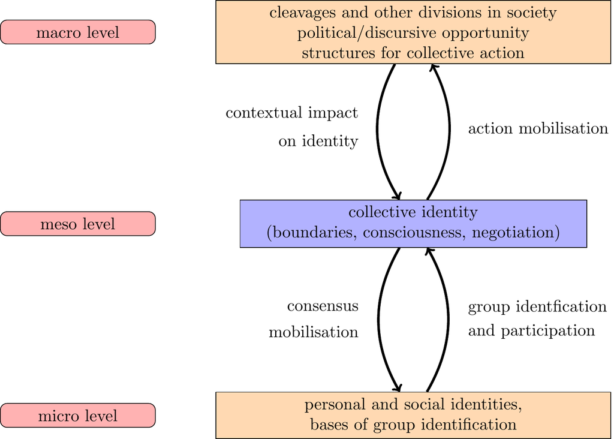

## Key concepts (7)

- **strategy** - a combination of a claim (or demand), a tactic, and a site (or venue); alternatively, consisting of 3 elements:
  1. *Targeting* - who/what is being acted upon by tactics
  2. *Tactics* - types of collective action and manner of their performance
  3. *Timing* - some moments present greater opportunity than others
  - Remember: strategy is a product of (rational) choice, BUT also a part of collective identity involving moral and emotional committments
  - demonstration vs. direct action
    - *Demonstrations* inconvenience or embarrass authorities and establish the movement’s social support but never themselves attain the collective goal
    - *Direct action* seize resources to satisfy their demands or take action to resolve a grievance; seeks itself to achieve collective goals

## Key concepts (8)

- Gamson (1990) found that violent social movements (incl. ‘strikes and disruptive techniques’) are more likely than nonviolent to achieve their goal
  - more effective in attracting attention and imposing costs on targets/opponents - similarly found by Cress and Snow (2000)
- Chenoweth and Stephan (2011): non-violent more than twice as likely to achieve full or partial success compared to violent cases
  - nonviolent campaigns elicit broad and diverse support, create more opposition defections, have more tactical options, often maintain discipline

## Key concepts (9)

- **social control hypothesis** (e.g., Piven and Cloward 1979)
  - disruptive protests/tactics allow movements to win concessions in exchange for ending protests/tactics (*coercion* mechanism)
- **mass mobilisation/social pressure hypothesis** (e.g., Chenoweth and Stephan 2011)
  - gaining enough (visible) support to pressure decision-makers into concessions (*consensus/demonstrative/persuasion* mechanisms)
    - implicit appeal to democratic norms
- **radical flank effects** - dynamics between (relatively) moderate and (relatively) radical parts of a movement and their target(s)
  - *positive* effect - compels target/authorities to accept moderate demands
  - *negative* effect - spooks potential elite allies

## Key concepts (10)

- McAdam (1983): tactical interaction
  - movements *disrupt* as they mount a challenge
  - authorities/targets *adapt* to tactics, dulling their impact
  - movements *innovate* tactics to maintain effective strategy
  - **this cycle places high demands on movements**

## Key concepts (11)

- **coalitions** - may be enduring, may be short-term
  - factors critical to coalition formation: social ties, conducive org. structures, ideology/culture/identity, institutional environment, resouces
  - help build/enhance networks, increase resource availability, expand tactical repertoires
- **media**
  - plays *gatekeeper* role
  - factors affective media coverage: day of week, other events, weather, celebrities, size/violence/counterdemo of event
- **astroturfing** - manipulation of public sphere (media, information, movement scene)

## Key concepts (12)

- **party responses to movements**: *dismissive*, *accommodative*, *adversarial/oppose*
- **state responses to movements**: ignore/dismiss, oppose (close opportunities, channel, repress), accommodate (encourage institutionalisation, engage in policymaking processes, change policy)

## Key concepts (13)

- dimensions of repression:

```r
library(tidyr)
library(kableExtra)

table_data <- tribble(
  ~a, ~b, ~c, ~d,
  "Identity of repressive agent", "State agents tightly connected with national political elites (e.g., military units)", "State agents loosely connected with national political elites (e.g., local police departments)",  "Private agents (e.g., counter-demonstrators)",

  "Character of repressive action", "Coercion (e.g., use of tear gas and rubber bullets)", "Channelling (e.g., restrictions on registered organisations)", "",

  "Whether repressive action is observable", "Observable (i.e., overt; e.g., Tiananmen Square)", "Unobserved (i.e., covert or latent; e.g., COINTELPRO)", "",
)

kable(table_data, "html", escape = FALSE,
      col.names = c("", "", "", "")) %>%
  kable_styling(bootstrap_options = c("striped", "hover", "responsive"), font_size = 28) %>%
  column_spec(1, bold = TRUE)
```

| Identity of repressive agent | State agents tightly connected with national political elites (e.g., military units) | State agents loosely connected with national political elites (e.g., local police departments) | Private agents (e.g., counter-demonstrators) |
| --- | --- | --- | --- |
| Character of repressive action | Coercion (e.g., use of tear gas and rubber bullets) | Channelling (e.g., restrictions on registered organisations) |  |
| Whether repressive action is observable | Observable (i.e., overt; e.g., Tiananmen Square) | Unobserved (i.e., covert or latent; e.g., COINTELPRO) |  |

## Key concepts (14)

- **countermovement** (‘opposing movements’) - a movement that makes contrary claims simultaneously to those of the original movement
  - involve sustained counter-mobilisation
  - characterised by *polarisation*, *dependency*, *Manicheism*, *imitation*
  - more likely to appear when… (a) originating movement shows signs of success, (b) that success includes threats to existing interests, (c) (elite) allies are available to support counter-mobilisation
  - divided governments/authorities are more likely to provoke movement-countermovement contention because they cannot decisively ‘close’ issues
  - federal systems are more likely to sustain movement-countermovement contention because there are venues/arenas
  - movements and countermovements form part of the opportunity structure of each other
- **critical events**, for movements, can be government or state actions, accidents/incidents, large or conspicuous demonstrations

## Key concepts (15)

- *internet tools* allow movements…
  - (+) greater speed (and accuracy) of communication, less cost of communication, greater connectivity across distances
  - (-) to scale up without building strong organisation
- **movement impact**
  - on individuals, on organisations, on cultures, on politics
    - positive, negative (backlash), null impacts

## Tips for preparing for Klausur

- review class slides
- reread your notes from readings
  - maybe (re-)read a couple of the required readings
- think through cases you know of
- think through other cases we discussed (through readings or your peers’ expertise)
- **don’t panic**

# Demobilisation and disengagement

- demobilisation and disengagement defined
- factors influencing demobilisation

[Break Car GIF](https://tenor.com/view/break-car-fall-apart-broken-ride-gif-4915243)from [Break GIFs](https://tenor.com/search/break-gifs)

## Demobilisation and disengagement defined

Demobilisation (Zeller 2026; cf. Davenport 2015)

> the process whereby collective action, whether in the form of campaigns, organisations, or even whole movements, decreases and ultimately ends

. . .

- *positive* demob. - after movement success
- *negative* demob. - with goals still unachieved

. . .

Disengagement (cf. Gaudette, Scrivens, and Venkatesh 2022; Fillieule 2009, 2015)

> the process by which an individual leaves their associated extremist group or movement

. . .

Note that these definitions cover *decline* and *cessation* of activity

## Factors influencing demobilisation

```r
library(kableExtra)
library(tidyverse)
## https://haozhu233.github.io/kableExtra/awesome_table_in_html.html

table_data <- data.frame(
  LP = c("*Burnout/exhaustion* (inability to continue participation)",
                 "*Lost commitment* (unwillingness to continue participation)",
                 "",
                 ""),
  OF = c("*Membership loss* (failure to recruit/retain members)",
                 "*Factionalisation* (internal splitting of organisations or coalitions)",
                 "*Rigidity* (failure to adapt according to new circumstances)",
                 ""),
  SC1 = c("(1) *Identity of",
          "State agents (actors representing state institutions)",
           "(2) *Character of",
           "Coercion (direct repression; the threat or use of force)"),
  SC2 = c("repressive agent*",
          "Private agents (actors not representing state institutions)",
          "repressive action*",
          "Channelling (indirect repression, such as resource deprivation, problem depletion)")
)

table_data <- data.frame(
  LP = c("Burnout/exhaustion",
         "(inability to continue participation)",
         "Lost commitment",
         "(unwillingness to continue participation)",
         "",
         ""),
  OF = c("Membership loss",
         "(failure to recruit/retain members)",
         "Factionalisation",
         "(internal splitting of organisations or coalitions)",
         "Rigidity",
         "(failure to adapt according to new circumstances)"),
  SC1 = c("(1) Identity of",
          "State agents (actors representing state institutions)",
           "(2) Character of",
           "Coercion (direct repression; the threat or use of force)",
          "",
         ""),
  SC2 = c("repressive agent",
          "Private agents (actors not representing state institutions)",
          "repressive action",
          "Channelling (indirect repression, such as resource deprivation, problem depletion)",
          "",
          "")
)

p <- kable(table_data, col.names = c("Lost Participation (individual level)", "Organisational Failure (group level)", "Social control", "(two dimensions)"),
      align = c("l", "l", "r", "l")) %>%
  add_header_above(header = c("Internal" = 2, "External" = 2)) %>%
  kable_minimal() %>%
  kable_styling(bootstrap_options = "striped", font_size = 24) %>%
  # kable_classic_2(full_width = F) %>%
  # column_spec(1:ncol(table_data), hline_after=F) %>%
  column_spec(1, border_right=T) %>%
  column_spec(2, border_right=T) %>%
  row_spec(0, bold = T, background = "grey80", hline_after = F) %>%
  row_spec(1, italic = T, color="darkred") %>%
  row_spec(3, italic = T, color="darkred") %>%
  row_spec(5, italic = T, color="darkred")
p
```

| Internal Lost Participation (individual level) | Internal Organisational Failure (group level) | External Social control | External (two dimensions) |
| --- | --- | --- | --- |
| Burnout/exhaustion | Membership loss | (1) Identity of | repressive agent |
| (inability to continue participation) | (failure to recruit/retain members) | State agents (actors representing state institutions) | Private agents (actors not representing state institutions) |
| Lost commitment | Factionalisation | (2) Character of | repressive action |
| (unwillingness to continue participation) | (internal splitting of organisations or coalitions) | Coercion (direct repression; the threat or use of force) | Channelling (indirect repression, such as resource deprivation, problem depletion) |
|  | Rigidity |  |  |
|  | (failure to adapt according to new circumstances) |  |  |

## Factors influencing demobilisation

*causes overlap and interact in different **demobilisation processes***

```r
p
```

| Internal Lost Participation (individual level) | Internal Organisational Failure (group level) | External Social control | External (two dimensions) |
| --- | --- | --- | --- |
| Burnout/exhaustion | Membership loss | (1) Identity of | repressive agent |
| (inability to continue participation) | (failure to recruit/retain members) | State agents (actors representing state institutions) | Private agents (actors not representing state institutions) |
| Lost commitment | Factionalisation | (2) Character of | repressive action |
| (unwillingness to continue participation) | (internal splitting of organisations or coalitions) | Coercion (direct repression; the threat or use of force) | Channelling (indirect repression, such as resource deprivation, problem depletion) |
|  | Rigidity |  |  |
|  | (failure to adapt according to new circumstances) |  |  |

## Factors influencing demobilisation

applicable to campaigns, organisations, whole movement sectors

```r
p
```

| Internal Lost Participation (individual level) | Internal Organisational Failure (group level) | External Social control | External (two dimensions) |
| --- | --- | --- | --- |
| Burnout/exhaustion | Membership loss | (1) Identity of | repressive agent |
| (inability to continue participation) | (failure to recruit/retain members) | State agents (actors representing state institutions) | Private agents (actors not representing state institutions) |
| Lost commitment | Factionalisation | (2) Character of | repressive action |
| (unwillingness to continue participation) | (internal splitting of organisations or coalitions) | Coercion (direct repression; the threat or use of force) | Channelling (indirect repression, such as resource deprivation, problem depletion) |
|  | Rigidity |  |  |
|  | (failure to adapt according to new circumstances) |  |  |

# Poll: Movement demobilisation

[figure not shown]

Take the survey at **https://forms.gle/cjgvb56HWrfWRzAL7**

- what to do if demands are met, goals achieved?
- most common factor leading to movement decline?
- achieved goals = demobilisation is likely?
- movements that fail to institutionalise are destined to demobilise sooner or later?
- institutionalisation = more effective pursuit of goals?

Questions about movements: (1) How would you describe the movement’s current level of mobilisation? (2) Has the movement successfully recovered after periods of decline? (3) What has been the most important demobilising pressure? (4) Has the movement become more institutionalised over time? (5) Even if mobilisation has declined, do the movement’s ideas remain influential?

```javascript
md`## Poll results (Respondents: ${respondentCount})`
```

[interactive chart not shown]

```javascript
import { liveGoogleSheet } from "@jimjamslam/live-google-sheet";
import { aq, op } from "@uwdata/arquero";

// UPDATE THE LINK FOR A NEW POLL
surveyResults = liveGoogleSheet(
  "https://docs.google.com/spreadsheets/d/e/" +
    "2PACX-1vQB00gFW5PK3umIX_FBaWj_WrSsHXqIjv-U94Qmuez5vcGupISgymKVq2Z61BWofmyFrRXPuUvMuHZN/" +
    "pub?gid=624052779&single=true&output=csv",
  10000, 1, 12); // adjust the last number to select all relevant columns

respondentCount = surveyResults.length;

likertOrder = [
  "Strongly disagree",
  "Disagree",
  "Neutral",
  "Agree",
  "Strongly agree"
];

ynmOrder = [
  "Yes",
  "No",
  "Maybe"
];

movementOrder = [
  "Antifa",
  "FFF",
  "LG",
  "PEGIDA",
  "Identitarians",
  "Querdenker"
];

movementColors = [
  "black",
  "green",
  "darkorange",
  "red",
  "gold",
  "purple"
];
```

[interactive chart not shown]

What should activists / movements do if their demands are met, goals achieved?

```javascript
MetDemands = aq.from(surveyResults)
  .select("demands_met")
  .filter(d => d.demands_met) // to exclude empty ("") strings, 0s, FALSEs, nulls, etc

MetDemands.array("demands_met")
```

[interactive chart not shown]

## Poll results

with achieved goals, demobilisation is likely?

```javascript
likely_demobCounts = aq.from(surveyResults)
  .select("likely_demob")
  .groupby("likely_demob")
  .count()
  .derive({ measure: d => "" })

// Calculate the maximum count from your dataset
likely_demob_maxCountRE = Math.max(...likely_demobCounts.objects().map(d => d.count));

plot_likely_demob = Plot.plot({
  marks: [
    Plot.barY(likely_demobCounts, {
      x: "likely_demob",
      y: "count",
      fill: "likely_demob",
      stroke: "black",
      strokeWidth: 1
    }),
    Plot.ruleY([respondentCount], { stroke: "#ffffff99" })
  ],
  color: {
    domain: [
      "Strongly disagree",
      "Disagree",
      "Neutral",
      "Agree",
      "Strongly agree"
    ],
    range: [
      "red",
      "pink",
      "lightgrey",
      "lightgreen",
      "forestgreen"
    ]
  },
  marginBottom: 180,
  x: { label: "", tickSize: 2, tickRotate: -45,
    domain: ["Strongly disagree", "Disagree", "Neutral", "Agree", "Strongly agree"]
  },
  y: {
    label: "",
    tickSize: 10,
    tickFormat: d => d,
    tickValues: Array.from(
      new Set(likely_demobCounts.objects().map(d => d.count))
    ).sort((a, b) => a - b),
    domain: [0, likely_demob_maxCountRE]
  },
  facet: { data: likely_demobCounts, x: "measure", label: "" },
  marginLeft: 140,
  style: {
    width: 1350,
    height: 500,
    fontSize: 30,
  }
});
```

[interactive chart not shown]

most common factor that leads to the decline of movements?

```javascript
common_factorCounts = aq.from(surveyResults)
  .select("common_factor")
  .groupby("common_factor")
  .count()
  .derive({ measure: d => "" })

// Calculate the maximum count from your dataset
common_factor_maxCountRE = Math.max(...common_factorCounts.objects().map(d => d.count));

plot_common_factor = Plot.plot({
  marks: [
    Plot.barY(common_factorCounts, {
      x: "common_factor",
      y: "count",
      fill: "common_factor",
      stroke: "black",
      strokeWidth: 1
    }),
    Plot.ruleY([respondentCount], { stroke: "#ffffff99" })
  ],
  color: {
    domain: [
      "weak leadership",
      "movement splits",
      "opposition from elites",
      "loss of public support",
      "other"
    ],
    range: [
      "goldenrod",
      "cadetblue",
      "darkorange",
      "forestgreen",
      "violet"
    ]
  },
  marginBottom: 400,
  x: { label: "", tickSize: 2, tickRotate: -40, padding: 0.2,
    domain: ["weak leadership", "movement splits", "opposition from elites", "loss of public support", "other"]
  },
  y: {
    label: "",
    tickSize: 10,
    tickFormat: d => d,
    tickValues: Array.from(
      new Set(common_factorCounts.objects().map(d => d.count))
    ).sort((a, b) => a - b),
    domain: [0, common_factor_maxCountRE]
  },
  facet: { data: common_factorCounts, x: "measure", label: "" },
  marginLeft: 60,
  style: {
    width: 1600,
    height: 500,
    fontSize: 40,
  },
});
```

[interactive chart not shown]

## Poll results - institutionalisation

movements that fail to institutionalise are destined to demobilise sooner or later?

```javascript
fail_instCounts = aq.from(surveyResults)
  .select("fail_inst")
  .groupby("fail_inst")
  .count()
  .derive({ measure: d => "" })

// Calculate the maximum count from your dataset
fail_inst_maxCountRE = Math.max(...fail_instCounts.objects().map(d => d.count));

plot_fail_inst = Plot.plot({
  marks: [
    Plot.barY(fail_instCounts, {
      x: "fail_inst",
      y: "count",
      fill: "fail_inst",
      stroke: "black",
      strokeWidth: 1
    }),
    Plot.ruleY([respondentCount], { stroke: "#ffffff99" })
  ],
  color: {
    domain: [
      "Yes",
      "No",
      "Maybe"
    ],
    range: [
      "forestgreen",
      "darkred",
      "goldenrod"
    ]
  },
  marginBottom: 80,
  x: { label: "", tickSize: 2, tickRotate: -1, padding: 0.2,
    domain: ["Yes", "No", "Maybe"]
  },
  y: {
    label: "",
    tickSize: 10,
    tickFormat: d => d,
    tickValues: Array.from(
      new Set(fail_instCounts.objects().map(d => d.count))
    ).sort((a, b) => a - b),
    domain: [0, fail_inst_maxCountRE]
  },
  facet: { data: fail_instCounts, x: "measure", label: "" },
  marginLeft: 60,
  style: {
    width: 1600,
    height: 500,
    fontSize: 40,
  },
});
```

[interactive chart not shown]

(cf. abeyance (Taylor 1989), ‘staying militant’ [e.g., MTST])

movement institutionalisation makes for more effective pursuit of goals?

```javascript
inst_more_effectiveCounts = aq.from(surveyResults)
  .select("inst_more_effective")
  .groupby("inst_more_effective")
  .count()
  .derive({ measure: d => "" })

// Calculate the maximum count from your dataset
inst_more_effective_maxCountRE = Math.max(...inst_more_effectiveCounts.objects().map(d => d.count));

plot_inst_more_effective = Plot.plot({
  marks: [
    Plot.barY(inst_more_effectiveCounts, {
      x: "inst_more_effective",
      y: "count",
      fill: "inst_more_effective",
      stroke: "black",
      strokeWidth: 1
    }),
    Plot.ruleY([respondentCount], { stroke: "#ffffff99" })
  ],
  color: {
    domain: [
      "Strongly disagree",
      "Disagree",
      "Neutral",
      "Agree",
      "Strongly agree"
    ],
    range: [
      "red",
      "pink",
      "lightgrey",
      "lightgreen",
      "forestgreen"
    ]
  },
  marginBottom: 180,
  x: { label: "", tickSize: 2, tickRotate: -45,
    domain: ["Strongly disagree", "Disagree", "Neutral", "Agree", "Strongly agree"]
  },
  y: {
    label: "",
    tickSize: 10,
    tickFormat: d => d,
    tickValues: Array.from(
      new Set(inst_more_effectiveCounts.objects().map(d => d.count))
    ).sort((a, b) => a - b),
    domain: [0, inst_more_effective_maxCountRE]
  },
  facet: { data: inst_more_effectiveCounts, x: "measure", label: "" },
  marginLeft: 140,
  style: {
    width: 1350,
    height: 500,
    fontSize: 30,
  }
});
```

[interactive chart not shown]

## Movement responses - current activity

movement’s current level of mobilisation

```javascript
m_current_mobilisationCounts = aq.from(surveyResults)
  .groupby("m_current_mobilisation", "movement")
  .count()
  .objects();

plot_m_current_mobilisation = Plot.plot({
  marks: [
    Plot.frame({
      fill: "#f7f7f7",
      stroke: "black",
      strokeWidth: 1
    }),

    Plot.barY(m_current_mobilisationCounts, {
      fx: "m_current_mobilisation",
      x: "movement",
      y: "count",
      fill: "movement",
      stroke: "white"
    })
  ],

  color: {
    domain: movementOrder,
    range: movementColors,
    legend: true,
    style: { fontSize: "20px" }
  },

  fx: {
    // domain: likertOrder,
    label: "",
    tickRotate: -45
  },

  x: {
    domain: movementOrder,
    axis: null, // clears the entire x-axis (ticks and labels)
    // tickFormat: () => "",
    label: ""
  },

  y: {
    label: ""
  },

  marginBottom: 250,
  style: {
    width: 900,
    height: 500,
    fontSize: 20
  }
});
```

[interactive chart not shown]

movement recovered after periods of decline

```javascript
m_recovered_after_declineCounts = aq.from(surveyResults)
  .groupby("m_recovered_after_decline", "movement")
  .count()
  .objects();

plot_m_recovered_after_decline = Plot.plot({
  marks: [
    Plot.frame({
      fill: "#f7f7f7",
      stroke: "black",
      strokeWidth: 1
    }),

    Plot.barY(m_recovered_after_declineCounts, {
      fx: "m_recovered_after_decline",
      x: "movement",
      y: "count",
      fill: "movement",
      stroke: "white"
    })
  ],

  color: {
    domain: movementOrder,
    range: movementColors,
    legend: true,
    style: { fontSize: "20px" }
  },

  fx: {
    domain: likertOrder,
    label: "",
    tickRotate: -55
  },

  x: {
    domain: movementOrder,
    axis: null, // clears the entire x-axis (ticks and labels)
    // tickFormat: () => "",
    label: ""
  },

  y: {
    label: ""
  },

  marginBottom: 140,
  style: {
    width: 900,
    height: 500,
    fontSize: 20
  }
});
```

[interactive chart not shown]

## Movement responses - demobilising pressure

most important demobilising pressure

```javascript
m_important_demob_pressureCounts = aq.from(surveyResults)
  .groupby("m_important_demob_pressure", "movement")
  .count()
  .objects();

plot_m_important_demob_pressure = Plot.plot({
  marks: [
    Plot.frame({
      fill: "#f7f7f7",
      stroke: "black",
      strokeWidth: 1
    }),

    Plot.barY(m_important_demob_pressureCounts, {
      fx: "m_important_demob_pressure",
      x: "movement",
      y: "count",
      fill: "movement",
      stroke: "white"
    })
  ],

  color: {
    domain: movementOrder,
    range: movementColors,
    legend: true,
    style: { fontSize: "20px" }
  },

  fx: {
    // domain: likertOrder,
    label: "",
    tickRotate: -45
  },

  x: {
    domain: movementOrder,
    axis: null, // clears the entire x-axis (ticks and labels)
    // tickFormat: () => "",
    label: ""
  },

  y: {
    label: ""
  },

  marginBottom: 250,
  style: {
    width: 900,
    height: 500,
    fontSize: 20
  }
});
```

[interactive chart not shown]

## Movement responses - movement institutionalisation

movement has become more institutionalised

```javascript
m_institutionalisedCounts = aq.from(surveyResults)
  .groupby("m_institutionalised", "movement")
  .count()
  .objects();

plot_m_institutionalised= Plot.plot({
  marks: [
    Plot.frame({
      fill: "#f7f7f7",
      stroke: "black",
      strokeWidth: 1
    }),

    Plot.barY(m_institutionalisedCounts, {
      fx: "m_institutionalised",
      x: "movement",
      y: "count",
      fill: "movement",
      stroke: "white"
    })
  ],

  color: {
    domain: movementOrder,
    range: movementColors,
    legend: true,
    style: { fontSize: "20px" }
  },

  fx: {
    domain: ynmOrder,
    label: "",
    tickRotate: 0
  },

  x: {
    domain: movementOrder,
    axis: null, // clears the entire x-axis (ticks and labels)
    // tickFormat: () => "",
    label: ""
  },

  y: {
    label: ""
  },

  marginBottom: 130,
  style: {
    width: 900,
    height: 500,
    fontSize: 20
  }
});
```

[interactive chart not shown]

## Movement responses - influential ideas

movement’s ideas remain influential

```javascript
m_ideas_influentialCounts = aq.from(surveyResults)
  .groupby("m_ideas_influential", "movement")
  .count()
  .objects();

plot_m_ideas_influential = Plot.plot({
  marks: [
    Plot.frame({
      fill: "#f7f7f7",
      stroke: "black",
      strokeWidth: 1
    }),

    Plot.barY(m_ideas_influentialCounts, {
      fx: "m_ideas_influential",
      x: "movement",
      y: "count",
      fill: "movement",
      stroke: "white"
    })
  ],

  color: {
    domain: movementOrder,
    range: movementColors,
    legend: true,
    style: { fontSize: "20px" }
  },

  fx: {
    domain: likertOrder,
    label: "",
    tickRotate: -55
  },

  x: {
    domain: movementOrder,
    axis: null, // clears the entire x-axis (ticks and labels)
    // tickFormat: () => "",
    label: ""
  },

  y: {
    label: ""
  },

  marginBottom: 140,
  style: {
    width: 900,
    height: 500,
    fontSize: 20
  }
});
```

[interactive chart not shown]

# Demobilisation cases

- campaigns
  - campaigns defined
  - far-right movement campaigns examples (Zeller 2026)
  - process tracing EDL case (Morrow and Meadowcroft 2018)

[Dominos Falling GIF](https://tenor.com/view/dominos-falling-gif-20582408)from [Dominos GIFs](https://tenor.com/search/dominos-gifs)

## Social movement campaigns

- Campaigns consist of four elements (della Porta and Rucht 2002; Staggenborg and Lecomte 2009)
  1. a consistent organising actor (an activist[s], an organisation[s]),
  2. temporal boundedness,
  3. strategically linked actions, and
  4. the intention to advance goals

. . .

- Campaigns…
  - are means for collective action to achieve objectives
  - shape collective identities [Polletta and Jasper (2001); Doherty and Hayes (2018), pp. 272, 278]
  - alter political opportunities and models of contention (Tilly 2008)

## Far-right demonstration campaigns (AT, DE, UK)

(Zeller 2026)

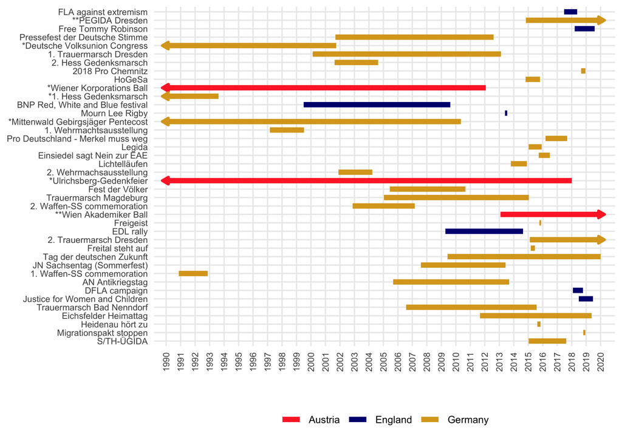

## Far-right demonstration campaigns (Zeller 2026)

**What might cause these campaigns to (negatively) demobilise?**

## Far-right demonstration campaigns (Zeller 2026)

**What might cause these campaigns to (negatively) demobilise?**

- concentrated state channelling (*SCH*)

## Far-right demonstration campaigns (Zeller 2026)

**What might cause these campaigns to (negatively) demobilise?**

- concentrated state coercion (*SCO*)
- concentrated state channelling (*SCH*)

## Far-right demonstration campaigns (Zeller 2026)

**What might cause these campaigns to (negatively) demobilise?**

- concentrated private channelling (*PCH*)
- concentrated state coercion (*SCO*)
- concentrated state channelling (*SCH*)

## Far-right demonstration campaigns (Zeller 2026)

**What might cause these campaigns to (negatively) demobilise?**

- concentrated private coercion (*PCO*)
- concentrated private channelling (*PCH*)
- concentrated state coercion (*SCO*)
- concentrated state channelling (*SCH*)

## Far-right demonstration campaigns (Zeller 2026)

**What might cause these campaigns to (negatively) demobilise?**

- long duration (*LD*) (on temporality, see Grzymala-Busse 2011)
- concentrated private coercion (*PCO*)
- concentrated private channelling (*PCH*)
- concentrated state coercion (*SCO*)
- concentrated state channelling (*SCH*)

## Far-right demobilisation patterns (Zeller 2026)

|  |  | inclS | PRI | covS | covU | cases |
| --- | --- | --- | --- | --- | --- | --- |
| closing opportunity | SCH | 0.977 | 0.977 | 0.408 | 0.097 | HoGeSa, Pressefest der Deutsche Stimme, Eichsfelder Heimattag; AN Antikriegstag; 2. Hess Gedenksmarsch; 1. Hess Gedenksmarsch; 2. Waffen-SS commemoration, Heidenau hört zu; Ulrichsbergfeier; Freital s… |
| state repression | ~LD* ~PCH | 1 | 1 | 0.136 | 0.087 | Freigeist; Sachsentag; 1. Waffen-SS commemoration; 1. Hess Gedenksmarsch |
| civil counter-mobilisation | ~PCO* PCH | 0.925 | 0.923 | 0.475 | 0.243 | Lichtelläufen Schneeberg, Free Tommy Robinson, FLA against extremism, Justice for Women and Children; HoGeSa, Pressefest der Deutsche Stimme, Eichsfelder Heimattag; 2. Hess Gedenksmarsch; Deutsche Vol… |
| anti-far-right militancy | LD* ~SCO* PCO | 1 | 1 | 0.214 | 0.146 | 2. Wehrmachtsausstellung; Trauermarsch Magdeburg, BNP Red, White and Blue festival, Wiener Korporations Ball, 1. Trauermarsch Dresden; Tag der deutschen Zukunft; Trauermarsch Bad Nenndorf |
|  | Solution | 0.949 | 0.948 | 0.893 |  |  |

## Far-right demobilisation patterns (Zeller 2026)

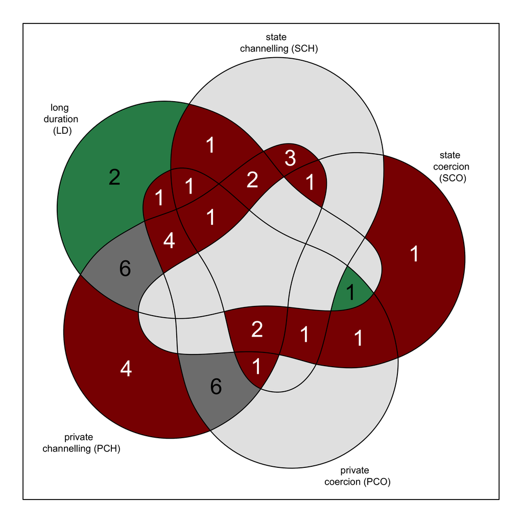

(negative) demobilisation

non-demobilisation

mixed outcomes

no cases

## FR demobilisation *processes* (Zeller 2026)

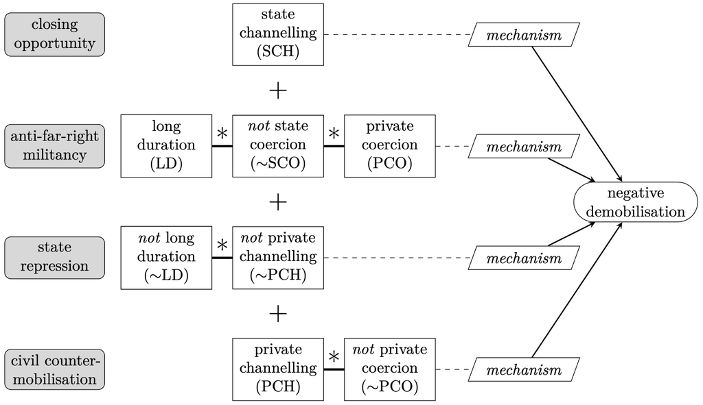

## Example of the EDL (Morrow and Meadowcroft 2018)

English Defence League (EDL)

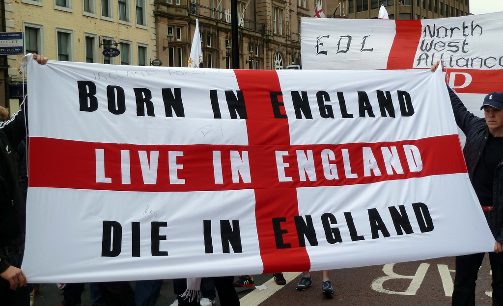

[figure not shown]

- important case: return to street politics, lots of successors (FLA, DFLA, Free Tommy Robinson, Justice for Women and Children)

## Example of the EDL (Morrow and Meadowcroft 2018)

[figure not shown]

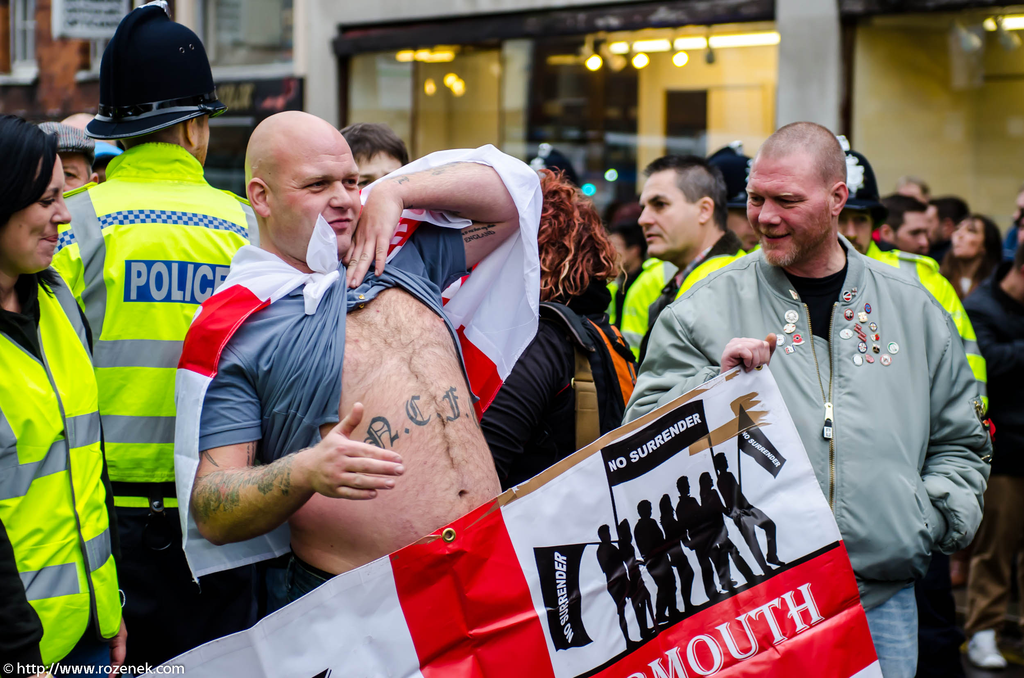

> rejection of pluralism and minority rights means [EDL] can properly be considered ‘far right’ (p545) (cf. Mudde 2019)

## EDL (Morrow and Meadowcroft 2018)

```
%%flowchart LR
%%  A["`EDL
%%  campaign
%%  kjaasdafjkjagk`"]:::greenBox --> B[reactive<br/>policing]:::yellowBox
%%  A --> C[counter-<br/>protest]:::yellowBox
%%  B --> D[public<br/>disorder,<br/>arrests]
%%  C --> D
%%  D --> E[preventative<br/>policing]:::yellowBox
%%  E --> F[EDL<br/>benefits<br/>reduced]

flowchart LR
  A[EDL<br/>campaign:<br/>violence,<br/>increased<br/>self-worth,<br/>solidarity]:::greenBox --> B[heavy,<br/>reactive<br/>policing]:::yellowBox
  A --> C[counter-<br/>demonstration<br/>activity]:::yellowBox
  B --> D[public disorder<br/>and numerous<br/>arrests]
  C --> D
  D --> E[policing<br/>adaptation:<br/>preventative]:::yellowBox
  E --> F[benefits to<br/>members esp.<br/>violence and<br/>group solidarity<br/>reduced]


  %% Style definitions - classDef blueBox fill:#d0e6ff,stroke:#003366,stroke-width:2px;
  %% classDef greenBox fill:#d4edda,height:150,width:160;
  %% classDef yellowBox fill:#fff3cd,height:100,width:70;
  classDef blueBox fill:#d0e6ff;
  classDef greenBox fill:#d4edda;
  classDef greyBox fill:#e2e3e5;
  classDef redBox fill:#f8d7da;
  classDef yellowBox fill:#fff3cd;
```

> From 2012, the police more effectively kept EDL and counter-demonstrations apart, and routed protests away from potential flashpoints such as Islamic centres

# Any questions, concerns, feedback for this class?

Anonymous feedback here: https://forms.gle/AjHt6fcnwZxkSg4X8

Alternatively, please send me an email: m.zeller@lmu.de

No questions about the assigned movements next meeting

## References

Chenoweth, Erica, and Maria J. Stephan. 2011. *Why Civil Resistance Works: The Strategic Logic of Nonviolent Conflict*. New York: Columbia University Press.

Cress, Daniel, and David Snow. 2000. “The Outcomes of Homeless Mobilization: The Influence of Organization, Disruption, Political Mediation, and Framing.” *American Journal of Sociology* 105 (4): 1063–1104.

Davenport, Christian. 2015. *How Social Movements Die*. Cambridge: Cambridge University Press. https://doi.org/10.1017/cbo9781139649728.

della Porta, Donatella, and Dieter Rucht. 2002. “The Dynamics of Environmental Campaigns.” *Mobilization: An International Quarterly* 7 (1): 1–14. https://doi.org/10.1007/978-3-319-53910-2_10.

Doherty, Brian, and Graeme Hayes. 2018. “Tactics and Strategic Action.” In *The Wiley Blackwell Companion to Social Movements*, edited by David A Snow, Sarah A Soule, Hanspeter Kriesi, and Holly J McCammon, 271–88. Hoboken: Wiley-Blackwell. https://doi.org/10.1002/9781119168577.ch15.

Fillieule, Olivier. 2009. “Disengagement from Radical Organizations. A Process and Multi-Level Model of Analysis.” In *Movements in Times of Transition*, edited by Bert Klandermans and Cornelius van Stralen, 1–29. Minneapolis: University of Minnesota Press.

———. 2015. “Demobilization and Disengagement in a Life Course Perspective.” In *The Oxford Handbook of Social Movements*, edited by Donatella della Porta and Mario Diani, 277–88. Oxford: Oxford University Press.

Gamson, William A. 1990. *The Strategy of Social Protest*. Belmont: Wadsworth Publishing.

Gaudette, Tiana, Ryan Scrivens, and Vivek Venkatesh. 2022. “Disengaged but Still Radical? Pathways Out of Violent Right-Wing Extremism.” *Terrorism and Political Violence* 00 (00): 1–26. https://doi.org/10.1080/09546553.2022.2082288.

Grzymala-Busse, Anna. 2011. “Time Will Tell? Temporality and the Analysis of Causal Mechanisms and Processes.” *Comparative Political Studies* 44 (9): 1267–97. https://doi.org/10.1177/0010414010390653.

Kitschelt, Herbert P. 1986. “Political Opportunity Structures and Political Protest: Anti-Nuclear Movements in Four Democracies.” *British Journal of Political Science* 16 (1): 57–85.

Koopmans, Ruud, and Susan Olzak. 2004. “Discursive Opportunities and the Evolution of Right-Wing Violence in Germany.” *American Journal of Sociology* 110 (1): 198–230. https://doi.org/10.1086/386271.

McAdam, Doug. 1983. “Tactical Innovation and the Pace of Insurgency.” *American Sociological Review* 48 (6): 735–54.

Morrow, Elizabeth A, and John Meadowcroft. 2018. “The Rise and Fall of the English Defence League: Self-Governance, Marginal Members and the Far Right.” *Political Studies* 67 (3): 539–56. https://doi.org/10.1177/0032321718777907.

Mudde, Cas. 2019. *The Far Right Today*. Cambridge: Polity Press.

Piven, Francis Fox, and Richard A Cloward. 1979. *Poor People’s Movements*. New York: Vintage Books.

Polletta, Francesca, and James M Jasper. 2001. “Collective Identity and Social Movements.” *Annual Review of Sociology* 27 (1): 283–305.

Staggenborg, Suzanne, and Josée Lecomte. 2009. “Social Movement Campaigns: Mobilization and Outcomes in the Montreal Women’s Movement Community.” *Mobilization: An International Quarterly* 14 (2): 163–80.

Tarrow, Sidney G. 2011. *Power in Movement: Social Movements and Contentious Politics*. Cambridge: Cambridge University Press. https://doi.org/10.1017/CBO9780511973529.

Taylor, Verta. 1989. “Social Movement Continuity: The Women’s Movement in Abeyance.” *American Sociological Review* 54 (5): 761–75.

Tilly, Charles. 2008. *Contentious Performances*. Cambridge: Cambridge University Press. https://doi.org/10.1017/CBO9780511804366.

Zeller, Michael C. 2026. *Demobilising the Far Right: Patterns and Processes from Demonstration Campaigns in Germany, England, and Austria*. Cambridge: Cambridge University Press.